# THE GLOBAL BIOGEOGRAPHY OF ROOTS - Schenk - 2002 - Ecological Monographs - Wiley Online Library

[Ecological Monographs](https://esajournals.onlinelibrary.wiley.com/journal/15577015)

[Volume 72, Issue 3](https://esajournals.onlinelibrary.wiley.com/toc/15577015/2002/72/3) p. 311-328

Regular Article

Full Access

# THE GLOBAL BIOGEOGRAPHY OF ROOTS

[H. Jochen Schenk](https://esajournals.onlinelibrary.wiley.com/authored-by/Schenk/H.+Jochen),

[Robert B. Jackson](https://esajournals.onlinelibrary.wiley.com/authored-by/Jackson/Robert+B.),

First published: 01 August 2002

https://doi.org/10.1890/0012-9615(2002)072[0311:TGBOR]2.0.CO;2

Citations: 683

## Abstract

Studies in global plant biogeography have almost exclusively analyzed relationships of abiotic and biotic factors with the distribution and structure of vegetation aboveground. The goal of this study was to extend such analyses to the belowground structure of vegetation by determining the biotic and abiotic factors that influence vertical root distributions in the soil, including soil, climate, and plant properties. The analysis used a database of vertical root profiles from the literature with 475 profiles from 209 geographic locations. Since most profiles were not sampled to the maximum rooting depth, several techniques were used to estimate the amount of roots at greater depths, to a maximum of 3 m in some systems. The accuracy of extrapolations was tested using a subset of deeply (>2 m) sampled or completely sampled profiles. Vertical root distributions for each profile were characterized by the interpolated 50% and 95% rooting depths (the depths above which 50% or 95% of all roots were located).

General linear models incorporating plant life-form dominance, climate, and soil variables explained as much as 50% of the variance in rooting depths for various biomes and life-forms. Annual potential evapotranspiration (PET) and precipitation together accounted for the largest proportion of the variance (12–16% globally and 38% in some systems). Mean 95% rooting depths increased with decreasing latitude from 80° to 30° but showed no clear trend in the tropics. Annual PET, annual precipitation, and length of the warm season were all positively correlated with rooting depths. Rooting depths in tropical vegetation were only weakly correlated with climatic variables but were strongly correlated with sampling depths, suggesting that even after extrapolation, sampling depths there were often insufficient to characterize root profiles. Globally, >90% of all profiles had at least 50% of all roots in the upper 0.3 m of the soil profile (including organic horizons) and 95% of all roots in the upper 2 m. Deeper rooting depths were mainly found in water-limited ecosystems. Deeper 95% rooting depths were also found for shrublands compared to grasslands, in sandy soils vs. clay or loam soils, and in systems with relatively shallow organic horizons compared with deeper organic horizons.

## Introduction

A century since the groundbreaking work of Schimper (1898) on “plant geography upon a physiological basis,” ecologists have made substantial progress in understanding the factors that shape the global distribution of vegetation and its aboveground structure (e.g., Box 1981, Woodward 1987, Prentice et al. 1992, Neilson 1995). The factors that control the biogeography of belowground vegetation structure remain less clear. For example, climate, soil characteristics, and plant life-forms are all likely to be important, but quantifying that importance at regional and global scales is difficult.

Vegetation types differ in root biomass, root turnover, vertical root distributions, and maximum rooting depth (Stone and Kalisz 1991, Canadell et al. 1996, Jackson et al. 1996, 1997, Vogt et al. 1996, Cairns et al. 1997). These properties influence the fluxes of water, carbon, and soil nutrients and the distribution and activity of soil fauna. Roots transport nutrients and water upwards, but they are also pathways for carbon and nutrient transport into deeper soil layers and for deep water infiltration (Johnston et al. 1983, Meek et al. 1992, Smith et al. 1999, Jobbágy and Jackson 2000, 2001). Roots also affect the weathering rates of soil minerals (Bormann et al. 1998).

To our knowledge, no large-scale analysis of the relationships between climate, soil, and vegetation with rooting depths has been attempted. Previous studies of rooting depths have examined data for particular locations or, in a few cases, for geographic regions (e.g., Weaver 1919, Shalyt 1950, Coupland and Johnson 1965, Baitulin 1979, Kutschera and Lichtenegger 1982). Other studies have examined rooting depth along climatic and/or elevational gradients without attempting to quantify the relationship of rooting depths with climate (Weaver 1977, Lichtenegger 1996, Schulze et al. 1996, Yanagisawa and Fujita 1999).

Regional and global data for rooting depth are also needed as inputs to global biogeochemistry and vegetation models. In the recent Project for Intercomparison of Land Surface Parameterization Schemes (PILPS), rooting depth and vertical soil characteristics were the most important factors explaining scatter for simulated transpiration among 14 land surface models (Mahfouf et al. 1996, Jackson et al. 2000*a*). Recently, the Terrestrial Observation Panel for Climate of the Global Climate Observation System (GCOS) identified the 95% rooting depth as a key variable needed to quantify the interactions between the climate, soil, and plants, stating that the main challenge was to find the correlation between rooting depth and soil and climate features (GCOS/GTOS Terrestrial Observation Panel for Climate 1997).

The goals of our study were two-fold: (1) to identify and, where possible, quantify biotic and abiotic factors that influence the vertical distribution of roots in the soil, and (2) to quantify vertical root distributions for global vegetation types. We examined these two questions in several contexts. One of them was the effect of plant life-form on rooting depths. Woody plants such as trees and shrubs on average tend to be more deeply rooted than grasses and forbs (Walter 1971, Jackson et al. 1996). Many vegetation and biogeochemistry models are parameterized with deeper maximum rooting depths or a greater proportion of roots at depth for woody plants (e.g., Dickinson et al. 1993, Neilson 1995, Haxeltine and Prentice 1996, Sala et al. 1997). We examined the basis for these generalizations globally, comparing the relative impact of plant life-form, soil, and climate on rooting depths. Such an analysis can help determine whether biotic or abiotic factors are better predictors of rooting depths. Another purpose of our analysis was to identify vegetation types where the potential mismatch between typical sampling depth and actual rooting depth appears to be particularly large. This information should allow researchers to target root sampling in particular systems.

## Methods

### The database of root profiles

The database of 115 root profiles described in Jackson et al. (1996) was expanded to include 475 root profiles for 209 geographical locations (Fig. 1; Appendix A) with data sets included if root samples were taken in at least four depth increments. For each root profile in Appendix A, we recorded latitude and longitude, soil texture and other soil characteristics, depth of organic horizons, type of roots measured (e.g., fine or total, live or dead), sampling method, units of measurements (root mass, length, number, surface area), and sampling depth. We also recorded the presence and dominance of plant life-forms as described in the publications (including succulents, forbs, grasses, semi-shrubs, shrubs, and four categories of trees: needle-leaved vs. broadleaved, evergreen vs. deciduous). Semi-shrubs were treated separately from shrubs because many studies made this distinction and because previous studies found differences in rooting depth between shrubs and semi-shrubs (Baitulin 1979, Nechaeva 1985, Leishman and Westoby 1992). We also noted whether the vegetation was relatively “natural” or altered by humans (e.g., forest plantations). Where unavailable, geographic coordinates were estimated based on geographic information in the publications. The precision of these estimates varied from a few kilometers in the majority of cases to no more than 0.5° latitude or longitude in a few cases (mostly for sites in unpopulated areas in boreal or tropical zones).

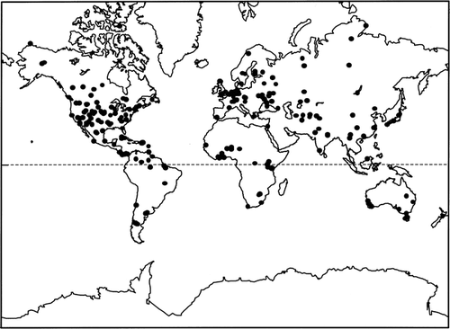

**Figure 1**

Open in figure viewer[PowerPoint](https://esajournals.onlinelibrary.wiley.com/action/downloadFigures?id=i0012-9615-72-3-311-f01&doi=10.1890%2F0012-9615%282002%29072%5B0311%3ATGBOR%5D2.0.CO%3B2)

Geographic locations of root profiles in the global database

Mean annual precipitation was recorded from each publication or, where unavailable, was estimated from the nearest available weather station. The seasonal distribution of precipitation was estimated from 1961–1990 long-term monthly means for 0.5° grid cells recorded in the Climate Research Unit (CRU) Global Climatologies (Intergovernmental Panel on Climate Change Data Distribution Center, University of East Anglia, Norwich, UK). Estimates for mean monthly potential evapotranspiration (PET) calculated by the Penman-Monteith method were taken from the global 0.5° gridded data set of Choudhury (1997) and Choudhury and DiGirolamo (1998). To estimate PET for sites in tropical cloud forests, mean values for a grid cell were halved to account for the effects of permanent cloud cover (Bruijnzeel and Proctor 1995).

Most profiles included roots from different species and life-forms. Where data were given separately for species or life-forms they were averaged to generate an estimated profile for the community, but the individual data were retained for the life-form analyses. Data for both late and early successional vegetation were included. Root profiles for crops and from fertilized or ploughed soils were excluded because root distributions in such systems can be strongly influenced by management practices, a factor that we were unable to include in our analyses. Also excluded were root profiles from wetlands and seasonally flooded desert playas, grasslands, savannas, and forests.

### Interpolation and extrapolation of root profiles

Root profiles differed in the number and depth of intervals sampled, which made standardizing them necessary so that statistical analyses could weigh each profile equally. To achieve this, profiles were interpolated by fitting a nonlinear smoothing function to each profile. Another issue was that only 9% of the 475 root profiles were sampled to a depth at which no further roots were found, with few studies sampling root profiles to depths of 3 m or more (Table 1). These incompletely sampled profiles (those not sampled to the maximum rooting depth or to at least 3 m depth) were extrapolated using the same mathematical function used to interpolate completely measured profiles. Tests of the accuracy of interpolations and extrapolations were conducted using 76 profiles sampled to at least 0.8 m depth *and* to depths at which no further roots were found *or* which had been sampled to ≥2 m depth (hereafter termed the “deep profiles”).

Table 1. Quantitative studies of vertical root distributions to sample depths of ≥3 m

The goal of interpolations and extrapolations was to estimate the depths above which 50% of all roots (*D*<sub>50</sub>) and 95% of all roots (*D*<sub>95</sub>) were located in the soil. All interpolations and extrapolations of profiles were restricted to a depth of 3 m, because this should be sufficient for most vegetation types (Canadell et al. 1996) and because our data set of deep profiles did not allow us to test the accuracy of extrapolation to greater depths. Details about the interpolation and extrapolation methods and tests of their error rates are in Appendix B. The nonlinear model used in this study for interpolation of deep profiles and for the interpolation and extrapolation of all other profiles was a logistic dose-response curve (LDR), which was fitted to cumulative root profiles:

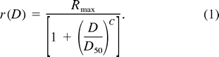

In this equation, *r*(*D*) is the cumulative amount of roots above profile depth *D* (in cm, including organic layers), *R*<sub>max</sub> is the total amount of roots (i.e., total biomass, length, number) in the profile, *D*<sub>50</sub> is the depth (cm) at which *r*(*D*) = 0.5 *R*<sub>max</sub>, and *c* is a dimensionless shape-parameter. The LDR model was fitted to all profiles, initially allowing *R*<sub>max</sub> to vary to obtain the best fit. To avoid excessive errors, extrapolations were restricted to a maximum sampling depth, *D*<sub>max</sub>, of either twice the sample depth or to 3 m depth, whichever was smaller, and the cumulative amount of roots at *D*<sub>max</sub> was set to 100%. Profiles sampled to the apparent maximum rooting depth or to ≥3 m were not extrapolated. Profiles for tundra were also not extrapolated beyond the measured depth because we assumed that permafrost was free of roots. Of all profiles, 20.0% were extrapolated to ≤1 m depth, 44.3% to between 1 m and ≤2 m, 14.7% to between 2 m and ≤3 m, and 21.0% were not extrapolated.

Seventy-six test profiles were used to derive bootstrapped estimates of the errors of mean extrapolated 50% and 95% rooting depths (see Appendix B; extrapolated rooting depths are hereafter denoted as *D*<sub>*x*50</sub> and *D*<sub>*x*95</sub>). To test whether vertical root distributions in the test profiles were representative of the whole data set, they were subsampled to a depth of ∼1 m, a typical sampling depth for the whole data set. (If the upper meter contained less than four sample intervals they were subsampled to 1.6 m at most.) Compared to the remaining database, root distributions within these ∼1 m-deep test samples did not differ from those found in other profiles measured to the same range of depths (see Appendix B). In consequence, root distributions in the upper ∼1 m portions of the test profiles appear to be representative of the database as a whole, which suggests that mean extrapolation errors observed for these profiles may also be representative of the entire database.

### Analyses of rooting depths as a function of climate, soil, and vegetation characteristics

Root profiles were initially grouped by location and physiognomy into 20 global vegetation types (Table 2). Root profiles were assigned to the climatic regions (arctic, boreal, cool-temperate, warm-temperate, or tropical) using the global climate classification schemes of Walter et al. (1975), Troll and Paffen (1980), and Bailey (1998). We chose the term “warm-temperate” (Troll and Paffen 1980) instead of the largely synonymous term “subtropical” (Bailey 1998).

Table 2. Global vegetation types used for grouping root profile data, and the number of profiles in the database for each type. Types delimited by aridity are listed with their mean annual precipitation limits

Mean rooting depths and their confidence intervals (95% ci) were calculated for all vegetation types with ten or more replicates. Differences among root profiles were compared within subsets of similar vegetation types along gradients of increasing temperature and/or aridity.

Profiles were also grouped by life-form (Table 3) to determine whether there were consistent differences among rooting depths of ecosystems dominated by trees, shrubs, semi-shrubs, and grasses. For this comparison, we chose two climatic ranges that encompass ecosystems dominated by all four of these life-forms, spanning from semi-deserts to dry forests in the temperate zone (>150–750 mm annual precipitation) and in the tropical zone (>250–1500 mm annual precipitation).

Table 3. Variables in correlation analyses and general linear models of rooting depths

Rooting depths were further analyzed for their relationships with climate, soil, vegetation, and sampling method (see Table 3). Because of limited detail in most of the profiles, soil texture was reduced to three categories: sand (including loamy and clayey sand), loam (sandy loam to silt-loam), and clay (including clay-loam and sandy clay). Quantitative information about the amounts of gravel and rocks in the soil were not available for most of the sites. Vegetation was grouped in five dominance categories: trees, shrubs, semi-shrubs (often co-dominant with herbaceous plants), grasses, or co-dominance of woody plants and grasses (i.e., tree–or shrub–savannas).

Climatic variables examined included precipitation and potential evapotranspiration. Effects of temperature were not examined separately, because they are strongly correlated with potential evapotranspiration. Of the various climatic parameters and indices that were tested for potential relationships with rooting depths, only those that showed significant relationships are discussed in this paper (Table 3). Correlations between *D*<sub>*x*50</sub> or *D*<sub>*x*95</sub> and environmental variables were examined by Spearman rank correlations in SYSTAT 8.0 (Wilkinson et al. 1998). To test whether extrapolations of rooting depths affected their relationships with environmental variables, the same correlation analyses were also conducted with the following data sets: Non-extrapolated rooting depths for the whole data set (*n* = 475), non-extrapolated rooting depths for all profiles sampled to the maximum rooting depth or to ≥2 m depth (*n* = 100), and extrapolated rooting depths of all profiles not sampled to the maximum rooting depth and sampled to <2 m depth (*n* = 375). Nonparametric correlation analysis was used to minimize the effects of unknown errors in both the dependent variable (rooting depths) and in the environmental variables. Probabilities were determined from Zar (1996).

General linear models (GLM) were constructed by backward stepwise regression to estimate the proportions of variances in rooting depths accounted for by vegetation type, life-form dominance, climate, soil, and sampling depth. Rooting depths were log-transformed to normalize their distributions. Vegetation type, life-form dominance, and soil texture were included in the models as categorical variables, and six transformed climatic variables were included as continuous variables (Table 3). Where noted, the data set was split into four subsets (tropical forests, tropical ecosystems not dominated by trees, temperate and boreal forests, and temperate and boreal ecosystems not dominated by trees) because exploratory analyses suggested that these subsets differed in their relationships between rooting depths and climatic variables. Because there are numerous potential errors for both the dependent and independent variables used in these linear models, we report only *r*<sup>2</sup> coefficients for the models with the highest *r*<sup>2</sup>. The proportion of the variance in rooting depths explained by sampling depths was estimated for each subset of the data by comparing general linear models that included sampling depth, vegetation type, life-form dominance, climate, and soil characteristics, with the best GLM that did not include sampling depth as a covariate.

### Effects of extrapolations on estimates of rooting depths

Rooting depths estimated by extrapolations of root distributions in the upper ∼1 m of the 76 test profiles were tightly correlated with rooting depths calculated by interpolation of the whole test profiles (Fig. 2A). Not surprisingly, total errors (including interpolation and extrapolation errors) of estimated mean rooting depths decreased with the number of profiles used to derive the estimate, from up to ±40% of the mean for samples of 10 profiles to less than ±10% of the mean for samples of 60 profiles or more (i.e., the more profiles in the analysis, the smaller the error; Fig. 2B). There was a slight tendency towards underestimating mean rooting depths by ∼1–3% (Fig. 2A and B). The 95% error ranges depicted in Fig. 2B were used to estimate bootstrapped 95% confidence limits (95% cl) for all mean rooting depths calculated in this study, depending on the number of profiles used to calculate the means. Confidence intervals were only calculated for sample sizes of ≥10 profiles (Fig. 2B).

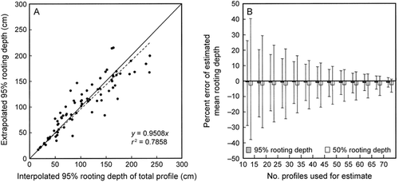

**Figure 2**

Open in figure viewer[PowerPoint](https://esajournals.onlinelibrary.wiley.com/action/downloadFigures?id=i0012-9615-72-3-311-f02&doi=10.1890%2F0012-9615%282002%29072%5B0311%3ATGBOR%5D2.0.CO%3B2)

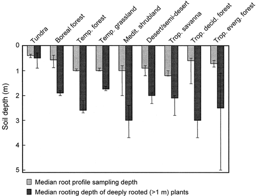

**Figure 3**

Open in figure viewer[PowerPoint](https://esajournals.onlinelibrary.wiley.com/action/downloadFigures?id=i0012-9615-72-3-311-f03&doi=10.1890%2F0012-9615%282002%29072%5B0311%3ATGBOR%5D2.0.CO%3B2)

Comparison between estimated rooting depths of global vegetation types and sampling depths used in quantitative studies of vertical root distributions. Rooting depths were estimated by calculating the median rooting depth of deeply rooted (≥1 m) plant species in that vegetation type from data contained in the database of Canadell et al. (1996) and Schenk and Jackson (2002). Median sampling depths were calculated from data in the global root profiles from this paper

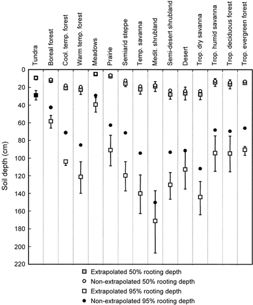

**Figure 4**

Open in figure viewer[PowerPoint](https://esajournals.onlinelibrary.wiley.com/action/downloadFigures?id=i0012-9615-72-3-311-f04&doi=10.1890%2F0012-9615%282002%29072%5B0311%3ATGBOR%5D2.0.CO%3B2)

Mean extrapolated and non-extrapolated rooting depths for global vegetation types (for definitions see Table 2). Extrapolated profiles are by definition deeper than non-extrapolated profiles. The extrapolations attempt to address the problem that many researchers sampled more shallowly than the entire root profile. Error bars represent 95% confidence intervals for means, based on sample sizes (listed in Table 2) and estimates of interpolation and extrapolation errors depicted in Fig. 2B. Cool-temperate forests include conifer and broadleaved-deciduous forests, as well as conifer plantations

### Methodological effects on estimates of rooting depths

Of all profiles in the database, 74% were in units of mass, 16% in units of numbers, 9% in units of length, and 1% in units of surface area. All measurements were expressed on an area basis at the soil surface (e.g., kg/m<sup>2</sup>) with the exception of the root number data, which were expressed as numbers per vertical profile area. Root number and root length data were common only in a subset of forest profiles. To check whether the choice of measurement units affected estimated rooting depths, we compared mean *D*<sub>*x*50</sub> and *D*<sub>*x*95</sub> values between profiles measured in different units for temperate forests, the only biome with enough profiles of different units.

Studies for woody vegetation often differed in whether fine roots, coarse roots, or total roots were measured (Appendix A). (Measurements of “total” roots usually excluded large skeletal roots in most profiles.) Simultaneous measurements of fine and coarse roots were available for 32 forest profiles. To compare distributions for fine and coarse roots in these profiles, we analyzed rooting depths for fine roots (<2 or 3 mm diameter), coarse roots (>2 or 3 mm), and total roots in paired *t* tests (fine vs. coarse and fine vs. total) using log-transformed data. To exclude any potential effects of extrapolation errors, non-extrapolated rooting depths *D*<sub>50</sub> and *D*<sub>95</sub> were used.

Forest root profiles for coarse roots differed in having deeper *D*<sub>50</sub> and shallower *D*<sub>95</sub> than fine root profiles. On average, *D*<sub>50</sub> for coarse roots were 54 ± 20% deeper than those for fine roots (*P* < 0.01), while *D*<sub>95</sub> for coarse roots were 12 ± 5% shallower than those for fine roots (*P* < 0.01). These results suggest that coarse woody roots, which have large effects on measurements in units of mass, tend to be concentrated in soil layers of shallow to medium depth, while the proportion of fine roots increases with depth. Many studies in the database lump fine and coarse roots (excluding large skeletal roots) into a measure of “total” roots. In forests, *D*<sub>50</sub> for total roots were 37 ± 13% deeper than those for fine roots (*P* < 0.01), while *D*<sub>95</sub> for total roots were similar to those of fine roots (5 ± 4% deeper; *P* = 0.08).

## Results

### Rooting depths of global vegetation types

Mean 50% rooting depths (*D*<sub>*x*50</sub>) for global vegetation types varied mostly between 5 cm and 28 cm (18 ± 1 cm, global mean ± 1 se; Fig. 4, Table 4). This result suggests that, on average, at least half of root biomass is found in the upper 30 cm of soil for all systems globally. Meadows and pastures in the forest zone, prairies, boreal forests, and tundra had the shallowest *D*<sub>*x*50</sub> (Figs. 4 and 5). Only 40 profiles in the database had *D*<sub>*x*50</sub> values of >40 cm, and the deepest *D*<sub>*x*50</sub> for the whole data set was 78 cm for a desert in Turkmenistan (Miroshnichenko 1975).

Table 4. Parameters for calculating vertical root distributions within the upper 3 m of the soil profile for global vegetation types using the logistic dose-response (Eq. 1)

Mean *D*<sub>*x*95</sub> varied mostly between 40 cm and 150 cm (Fig. 4), with a global mean of 102 cm (±4 cm se). Tundra, boreal forests, and meadows in the temperate forest zone had mean *D*<sub>*x*95</sub> of <60 cm, while mediterranean shrublands and woodlands, temperate savannas, and dry tropical savannas had the deepest mean *D*<sub>*x*95</sub> of >140 cm. Individual *D*<sub>*x*95</sub> values of >200 cm depth were observed in 8% of all profiles in the database, primarily in deserts and semi-deserts, mediterranean shrublands and woodlands, temperate savannas, and tropical systems.

In general, boreal forests were much more shallowly rooted than temperate forests (Fig. 5A). Warm-temperate forests had slightly deeper *D*<sub>*x*95</sub> values than cool-temperate forests, but rooting depths for all temperate forests were similar (Figs. 4 and 5A). No differences were found within these vegetation types for comparisons of deciduous and evergreen trees, broadleaved and needle-leaved trees, or plantations and natural forests. Rooting depths for meadows and pastures in the temperate and boreal forest zone, prairies, and semi-arid steppe increased in depth along an aridity gradient from wet to dry (Fig. 5B).

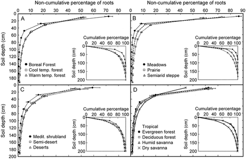

**Figure 5**

Open in figure viewer[PowerPoint](https://esajournals.onlinelibrary.wiley.com/action/downloadFigures?id=i0012-9615-72-3-311-f05&doi=10.1890%2F0012-9615%282002%29072%5B0311%3ATGBOR%5D2.0.CO%3B2)

Extrapolated root profiles for 13 global vegetation types. The large graphs are non-cumulative profiles, and the insets are cumulative profiles. For sample sizes see Table 2. Error bars represent ±1 se. No differences in rooting depths were found among cool-temperate broadleaved forests, conifer forests, and conifer plantations, and these three categories were combined into one global vegetation type termed “cool-temperate forests” in panel (A)

Mediterranean shrublands and woodlands had the deepest mean *D*<sub>*x*95</sub> values of all vegetation types (Fig. 4), but this result was largely due to two root profiles of Eucalyptus marginata woodlands in southwestern Australia measured to 15 m and 18 m (Carbon et al. 1980). Without these two profiles, the mean *D*<sub>*x*95</sub> was reduced to 109 cm with a 95% confidence interval for the mean of about ±22 cm. Mediterranean shrublands and woodlands had higher proportions of roots at shallow depths than semi-deserts or deserts (Fig. 5C).

Dry tropical savannas had much deeper profiles than the three more humid tropical types, which had similar root profiles (Fig. 5D). Tropical cloud forests (*n* = 8; mean *D*<sub>*x*50</sub> = 7 cm; mean *D*<sub>*x*95</sub> = 46 cm) were more shallowly rooted than tropical lowland forests.

Rooting depths for additional vegetation types were determined only for a few profiles, which does not allow calculation of confidence limits for mean rooting depths. Heathlands appear to be shallowly rooted (*n* = 5; mean *D*<sub>*x*50</sub> = 11 cm; mean *D*<sub>*x*95</sub> = 73 cm) as are alpine communities (*n* = 9; mean *D*<sub>*x*50</sub> = 9 cm; mean *D*<sub>*x*95</sub> = 71 cm).

### Relationships between climatic variables and rooting depths

On average, *D*<sub>*x*95</sub> values increased with decreasing latitude between 80° and ∼30° north or south latitude (amidst much variation) but showed no clear trend for tropical latitudes between 0° and 30° (Fig. 6). There was a conspicuous lack of shallow *D*<sub>*x*95</sub> of <40–50 cm between ∼20° and 32° latitude, a zone encompassing mostly dry ecosystems (Bailey 1998). With the exception of this latitudinal belt, shallow *D*<sub>*x*95</sub> values were common throughout the data set independent of climate (Figs. 6 and 7). However maximum *D*<sub>*x*95</sub> values increased with decreasing latitude, warm season length, and increasing annual PET (Tables 5 and 6). These two patterns caused a roughly fan-shaped relationship of rooting depths with annual PET (Fig. 7).

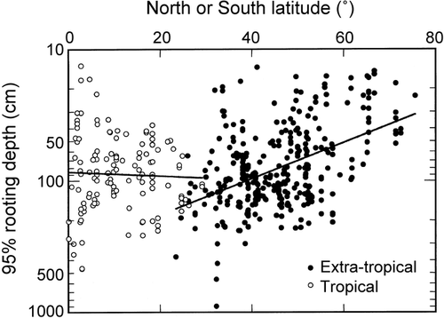

**Figure 6**

Open in figure viewer[PowerPoint](https://esajournals.onlinelibrary.wiley.com/action/downloadFigures?id=i0012-9615-72-3-311-f06&doi=10.1890%2F0012-9615%282002%29072%5B0311%3ATGBOR%5D2.0.CO%3B2)

Extrapolated 95% rooting depths (*n* = 475) as a function of latitude

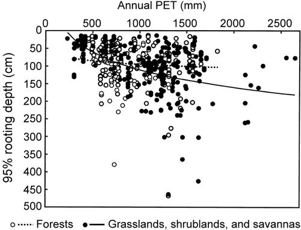

**Figure 7**

Open in figure viewer[PowerPoint](https://esajournals.onlinelibrary.wiley.com/action/downloadFigures?id=i0012-9615-72-3-311-f07&doi=10.1890%2F0012-9615%282002%29072%5B0311%3ATGBOR%5D2.0.CO%3B2)

Extrapolated 95% rooting depths (*n* = 475) for global forests and non-forest vegetation (grasslands, shrublands, and savannas) as a function of annual potential evapotranspiration. The trend lines were calculated by logarithmic equations of the form (*y* = *a* ln *x* − *b*). The *r*<sup>2</sup> coefficients for the two trend lines are: forests (dashed line) = 0.007, non-forest vegetation (solid line) = 0.146

Table 5. Spearman rank correlation coefficients for correlations of extrapolated 50% and 95% rooting depths (*D*<sub>*x*50</sub> and *D*<sub>*x*95</sub>) with environmental variables (see Table 3 for definitions of variables)

The relationships of climatic variables with maximum rooting depths within a given climatic range were clearer than with mean rooting depths (Table 6). Deep *D*<sub>*x*95</sub> values of >1.5 m were only found in climates with warm seasons of six months or longer and never in climates with annual precipitation >3000 mm. The deepest *D*<sub>*x*95</sub> values of >2.4 m were found at latitudes below 39° in climates with eight warm months and <1800 mm annual precipitation.

Table 6. Climatic limits for the occurrence of 95% rooting depths exceeding 0.3, 0.6, 0.9, 1.2, 1.5, 2.1, and 2.4 m

Length of the warm season, annual PET, precipitation, precipitation surplus, latitude, and the depth of the organic layer were significantly (*P* < 0.05) correlated with rooting depths of arctic, boreal, and temperate vegetation (Table 5). Grasslands, shrublands, and savannas had rooting depths that were strongly correlated with almost all of these same variables, but the relationships for forests were weaker. The length of the dry season was correlated with rooting depths in non-forest vegetation. For temperate, boreal, and arctic systems in general, rooting depths increased significantly with increasing length of the warm season and annual PET and decreased with increasing latitude and depth of the organic layer (Table 5). Rooting depths in forests increased with increasing annual precipitation and precipitation surplus, but generally showed the reverse trend in non-forest vegetation.

Relationships of rooting depths with environmental variables were generally weaker for tropical vegetation, especially with annual PET and the length of the warm season (Table 5). These results may reflect the narrower range of these variables in the tropics. In contrast, annual precipitation was generally more strongly correlated with rooting depths in tropics than outside the tropics. Rooting depths in the tropics were negatively correlated with annual precipitation and mostly positively correlated with the length of the dry season. Tropical forests showed a strongly negative correlation of *D*<sub>*x*95</sub> with the depth of the organic layer, but no effects of the organic layer on *D*<sub>*x*50</sub>.

### Rooting depth and soil characteristics

Of the six vegetation types in Table 2 with enough replicates to compare rooting depths and soil texture, sandy soils had deeper *D*<sub>*x*95</sub> values than loam or clay soils in boreal forests, cool-temperate forests, semi-desert shrublands, deserts, and dry tropical savannas (Fig. 8). The only system where this was not the case was tropical evergreen forest, which apparently had shallower rooting depths in sandy soils.

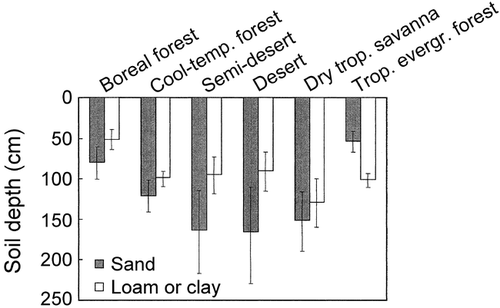

**Figure 8**

Open in figure viewer[PowerPoint](https://esajournals.onlinelibrary.wiley.com/action/downloadFigures?id=i0012-9615-72-3-311-f08&doi=10.1890%2F0012-9615%282002%29072%5B0311%3ATGBOR%5D2.0.CO%3B2)

Extrapolated 95% rooting depths for six global vegetation types with measurements in both sandy and fine-textured (loam to clay) soils. Error bars represent 95% confidence intervals for means, based on sample sizes and estimates of interpolation and extrapolation errors depicted in Fig. 2B

Organic horizons contained substantial amounts of roots in all forest types. Forest profiles had an average of 16 ± 3% of fine roots in organic horizons (*n* = 92), and 17 ± 2% of total roots (*n* = 142). Mean depths of the organic horizons containing roots (usually excluding the L layer of undecomposed litter) were 11.0 ± 1.9 cm (*n* = 29) for boreal forests, 4.0 ± 0.7 cm (*n* = 60) for cool-temperate forests, 0.7 ± 0.3 cm (*n* = 20) for warm-temperate forests, and 3.9 ± 0.9 cm (*n* = 80) for tropical forests. Rooting depths decreased in all forest systems as the depth of organic horizons increased (Table 5).

### General Linear Models of rooting depths

Of the variables examined globally, climatic variables explained the greatest proportion of variation for rooting depths in the general linear model (GLM) analysis (Table 7). Climate variables explained ∼20% of the variance in *D*<sub>*x*50</sub> and *D*<sub>*x*95</sub> on average, explaining substantially more variance for vegetation not dominated by trees (>30%) than for tree-dominated vegetation (Table 7). Globally, soil characteristics were correlated relatively weakly with rooting depths, and effects were stronger in vegetation not dominated by trees. The most important soil factor globally was the depth of the organic horizon for 95% rooting depths, with soil texture contributing little globally (and in contrast to the strong effects of texture within systems; Fig. 8). Life-form dominance classes also had low correlation coefficients with rooting depths globally. The strongest influence of life-forms was on *D*<sub>*x*50</sub> values outside the tropics, which reflected the strong difference in *D*<sub>*x*50</sub> between grasslands and forests (Fig. 4). The combination of life-form dominance with climate and soil variables explained ∼30% of the variance in rooting depths on average. Vegetation type alone explained almost as much of the variance in rooting depths as the combination of life-form dominance class with climate and soil, probably because ecosystems within vegetation types tend to share climate and soil characteristics. Models including both vegetation type and climatic variables on average had the strongest correlations with rooting depths, explaining 35–51% of the variance in 95% rooting depths for all vegetation types except tropical forests.

Table 7. Proportion of the variances explained in general linear models of extrapolated 50% and 95% rooting depths as functions of six climatic variables, two soil variables, and life-form dominance classes (Table 3), vegetation types (Table 2), and sampling depths

Extrapolations of rooting depths had no effect on the strengths of their relationships with environmental variables. Correlation coefficients were not significantly different for correlations using extrapolated rooting depths than for those using non-extrapolated ones (Fig. 9; Appendix C, Table C1). Non-extrapolated rooting depths in the subset of profiles that were sampled to the maximum rooting depth or to ≥2 m largely showed the same correlations with environmental variables as did the extrapolated rooting depths of that subset of profiles that did not fit these criteria (Appendix C, Table C2). One notable exception was the lack of a correlation between extrapolated 95% rooting depths and latitude, which apparently was caused by the scarcity (*n* = 8) of deep (>2 m) *D*<sub>*x*95</sub> in this data set of 375 extrapolated profiles.

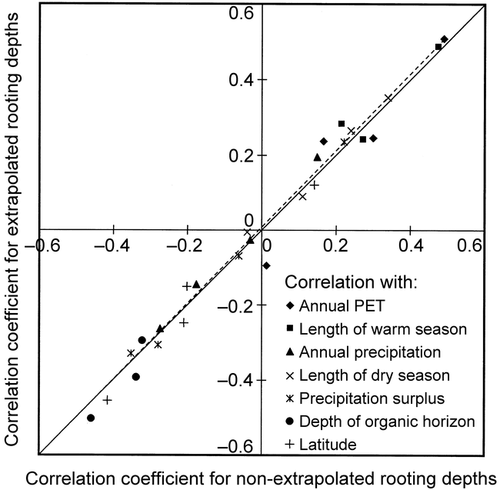

**Figure 9**

Open in figure viewer[PowerPoint](https://esajournals.onlinelibrary.wiley.com/action/downloadFigures?id=i0012-9615-72-3-311-f09&doi=10.1890%2F0012-9615%282002%29072%5B0311%3ATGBOR%5D2.0.CO%3B2)

Effects of sampling depths on extrapolated estimates of rooting depths were examined using the differences between *r*<sup>2</sup> coefficients of GLMs that did and did not include sampling depth. In boreal and temperate ecosystems, sampling depths explained 11–12% of the variance in *D*<sub>*x*95</sub> in addition to the proportion explained by abiotic and biotic variables, which ranged from 39% to 51% (Table 7). In tropical ecosystems, sampling depths explained a far greater proportion of the variance in *D*<sub>*x*95</sub>, between 26% and 31%, suggesting a fairly strong methodological bias in the estimates of tropical rooting depths. This result and the evidence that tropical samples are often under-sampled with respect to depth (Fig. 3) highlight the need for better estimates of rooting depth in tropical systems.

## Discussion

Of all the biotic and abiotic factors examined, climate explained the largest proportion of global variation in rooting depths (Table 7). A large part of that variation correlated strongly with climatic variables that characterize supply and evaporative demand for water. Differences in life-forms between sites accounted for the next largest proportion of the observed variation. This proportion may also be due in part to climate, because differences in the life-form dominance of ecosystems are driven in part by climatic factors (Woodward 1987, Box 1996). Differences in soils explained very little of the variation in rooting depths globally, but this may be due in part to a lack of detailed information on soil characteristics. They were quite important for results within ecosystems or vegetation types (Fig. 8).

### On the interpretation of 95% rooting depths

*D*<sub>95</sub> values are a measure of the soil depth that holds the bulk of roots, but they are not necessarily closely correlated with maximum rooting depths. Consider the example of temperate grasslands. Semi-arid steppes with ≤500 mm annual precipitation had significantly deeper *D*<sub>*x*95</sub> values than prairies with >500 mm precipitation (Fig. 4), but relative root densities below 1.4 m were similar in the two systems (Fig. 5B). Data from Weaver and colleagues show that maximum rooting depths of species in North American grasslands with >500 mm precipitation are on average 2.3 ± 0.2 m (*n* = 66), while species in grasslands with ≤500 mm reach only 1.8 ± 0.1 m (*n* = 64) (Weaver 1919, 1920, 1954, 1958, Weaver and Darland 1949). Thus according to the Weaver data set, the absolute depth reached by roots in prairies is greater than in semi-arid grasslands. Our data add additional information to the data of Weaver and colleagues by showing that the bulk of roots in prairie is located much more shallowly than in semi-arid grasslands (Fig. 5B). These results raise important questions about the functional importance of the deepest 5% of root systems in grasslands and elsewhere. In most systems, the bulk of root activity will be restricted to the zone of 95% rooting depth, but the deepest 5% of roots may contribute an important percentage of ecosystem transpiration in some environments (Stone and Kalisz 1991, Nepstad et al. 1994, Jackson et al. 1999). A possible example is the case where a few deeply rooted plants make water available to more shallowly rooted plants through hydraulic lift (Caldwell et al. 1998).

### General patterns in global rooting depths

Only ∼6% of all profiles in the database had lower root densities in the upper 20 cm of the profile than in the interval from 20 cm to 40 cm. Of these, more than four-fifths were in deserts, savanna, grasslands, or dry forests with at least one arid month during the growing season (mean 6.1 ± 0.7 mo). These are ecosystems where the upper soil horizons are likely to be too dry for resource uptake during part of the growing season.

Our data suggest that globally 95% of all roots are within 2 m of the soil surface, which was the case in 92% of all profiles. However only 18 studies in the database sampled root profiles to 3 m or more (Table 1), and more importantly only 9% of the 475 root profiles were sampled to a depth at which no further roots were found. This made it necessary to extrapolate profiles in order to estimate the amounts of roots at greater depths. It also highlights the gap in current knowledge for the placement and functioning of relatively deep roots. *D*<sub>95</sub> values >2 m are likely more common than suggested by the data in this study. About 30% of the variance in extrapolated *D*<sub>*x*95</sub> for tropical ecosystems is explained by sampling depth, which suggests that many tropical root profiles are sampled too shallowly to allow adequate estimates of *D*<sub>95</sub>. Extrapolations of root profiles in seasonally dry tropical environments are often difficult because they tend to have high root densities close to the soil surface and nearly constant densities from 1 m to ≫2 m depth (Kellman and Roulet 1990, Vandenbeldt 1991, Nepstad et al. 1994, Sternberg et al. 1998). Estimates of *D*<sub>95</sub> in such profiles are highly dependent on the cutoff depth chosen for extrapolation. There clearly is an important need for more studies of deep root distributions and functioning in tropical environments.

There was no significant difference between *D*<sub>95</sub> for fine and total roots in forests, which suggests that errors introduced by combining these measurements in our analyses were likely small. But *D*<sub>50</sub> values in forests were slightly deeper for total than for fine roots, suggesting that some of the estimates for *D*<sub>*x*50</sub> in woody vegetation (e.g., Fig. 4 and Table 4) may be ∼3–6 cm deeper than they would be for fine roots alone.

### Effects of climate on rooting depths for vegetation types

Mean and maximum *D*<sub>95</sub> values increased with decreasing latitude from arctic regions to the edge of the tropical climatic zone (Fig. 6, Table 6). This increase appears to be primarily driven by warmer temperatures, longer growing seasons, and increased evaporative demand. These climatic factors largely explain the increase in mean rooting depths from boreal to cool- and warm-temperate forests (Fig. 5A).

Differences in rooting depths between and within tropical vegetation types appear to be less pronounced than between and within arctic, boreal, and temperate ones (Fig. 4). However tropical cloud forests and floodplain forests are apparently more shallowly rooted than the drier vegetation types examined in this study, and it is likely that rooting depths in the tropics are as variable as the soil water regimes in this zone. In general, root profiles in the tropics become shallower with increased precipitation and precipitation surplus, and become deeper in systems with a longer dry season (Table 5). Rooting depths in the tropics were more highly correlated with precipitation than with PET, suggesting that they are driven more by water supply than by uniformly high evaporative demand (generally >1000 mm of PET per year, except in cloud forests).

Water supply and demand appear to have a stronger influence on rooting depths in non-forest vegetation than in forests (e.g., Fig. 7), likely because forests tend to grow under conditions where water is less limiting. For example, the degree of aridity (e.g., length of the dry season) was highly correlated with rooting depths in temperate and boreal grasslands, shrublands, and savannas, but not in temperate and boreal forests (Table 5). Precipitation appears to be the driving factor for differences in rooting depths between prairies and semi-arid steppes, which occur at similar latitudes with similar evaporative demands (Sims et al. 1978). The mean depth of infiltration is often smaller in semi-arid grasslands than in more humid ones, but the upper soil layers are also more likely to be dry during parts of the growing season (Sala et al. 1992). Meadows and pastures in the forest zone tend to be even more humid than prairies and have lower evaporative demands, which may explain their shallower root profiles (Figs. 4 and 5B).

Within a climatic zone (i.e., boreal, temperate, tropical), arid and semi-arid systems tend to have deeper 50% and 95% rooting depths than humid ones (Fig. 4). This probably reflects a tendency in water-limited ecosystems for plants to access water that was stored at depth during occasional or seasonal wet periods. This may also explain why 95% rooting depths in deserts are shallower than in semi-arid systems, such as temperate and tropical dry savanna and mediterranean shrublands and woodlands (Fig. 4). The main limit to rooting depths in arid ecosystems may be the depth of water infiltration, which can be extremely shallow on slopes and can be quite deep in low-lying areas. The profiles in our database were mostly from relatively level sites that are unlikely to receive or contribute much runoff or lateral movement of water (though few studies measure lateral movement directly). Rooting depths can be very deep locally in periodically flooded desert playas (Freckman and Virginia 1989), but we classified such sites as wetlands and did not include them in our analysis. Differences in the depth of infiltration may also partly explain the observation that water-limited ecosystems tended to have deeper roots in coarse-textured than in fine-textured soils (Fig. 8), because coarse-textured soils have lower water-holding capacities and water tends to percolate more deeply. Other factors being equal, rooting depths are predicted to be deeper in coarse textured soils based on the hydraulic properties of plants and the soil (Sperry et al. 1998, Jackson et al. 2000*b*).

Vertical root distributions in water-limited systems may be poorly correlated with long-term means of precipitation because of the importance of interannual variation in rainfall (Williams and Ehleringer 2000). Rooting depths in water-limited systems may be substantially deeper than the average depth of infiltration predicted just from annual mean precipitation, in part because plants in such systems are most active in wet years with deep infiltration. Vertical root distributions in such ecosystems may perhaps be better predicted using long-term frequency distributions of precipitation rather than mean annual water infiltration depths.

### Effects of plant life-forms on rooting depths

Studies of rooting depths for individual species have clearly shown that woody plants are, on average, more deeply rooted than herbaceous ones (e.g., Shalyt 1952, Baitulin 1979, Kutschera and Lichtenegger 1997, Schenk and Jackson 2002). However this statement may be more valid for comparisons of maximum rooting depths of woody and herbaceous life-forms than for 95% rooting depths of life-forms co-occurring within a given ecosystem. The 14 root profiles in our database that have separate information on roots of woody plants and grasses from the same sites included six that have about equal *D*<sub>95</sub> for both, three with deeper *D*<sub>95</sub> for woody plants, and five with deeper *D*<sub>95</sub> for grasses. Studies comparing water use of co-occurring plant life-forms have shown that woody plants took up water from deeper layers than herbaceous ones in some systems (Sala et al. 1989, Ehleringer et al. 1991), but not in others (Le Roux et al. 1995, Le Roux and Bariac 1998).

For comparisons among different sites, our data support the hypothesis that forests and shrublands are on average more deeply rooted than grasslands, but only for temperate regions (although comparisons of rooting depths among tropical sites may be hampered by insufficient sampling depths). Overall, differences in 95% rooting depths between shrublands and grasslands under similar climatic conditions were less pronounced than the differences in maximum rooting depths commonly observed between shrubs/semi-shrubs and grasses (e.g., Baitulin 1979, Schenk and Jackson 2002). The reasons for this may include that deep roots in woody plants likely constitute only a small percentage of all roots and that “shrubland” and “grassland” ecosystems, their names notwithstanding, often contain mixed woody and herbaceous plants.

For predictions on a global scale it may be undesirable to assign fixed rooting depths to life-forms or to simple life-form dominance classes, such as grasslands, shrublands, or forests. In our analysis, 95% rooting depths were more strongly related to climatic variables than to life-form dominance classes (Table 7). For example, grasslands were on average more deeply rooted in tropical regions than in temperate ones.

### Rooting depths in vegetation and biogeochemistry models

The data for global vegetation types summarized in Fig. 4 and Table 4 are potentially useful in global biogeography and biogeochemistry models and in land surface parameterization schemes for general circulation models (Zeng et al. 1998, Jackson et al. 2000*a*), but there are some caveats. Current models generally allow for maximum rooting depths of 1 m to 2 m, similar to the 95% rooting depths determined in this study (Jackson et al. 2000*a*). However the remaining 5% of roots may reach much greater depths in some ecosystems, and our results showing the strong effects of climate on rooting depths suggest that many systems may have at least some species that reach water at depth if it is available and if there is evaporative demand for it. Simulated transpiration rates in global models are often sensitive to estimated rooting depths (Jackson et al. 2000*a*), and more comparisons of field measurements with modeled data are needed to determine whether it is better to use maximum rooting depths (e.g., Table 6) or mean rooting depths (e.g., Table 4) in models. Users of our data should bear in mind that rooting depths varied greatly among sites and that our models accounted for at most 50% of the observed variance.

Models that use fixed, mean rooting depths may predict water limitations under scenarios that increase evaporative demands because they do not allow roots to access water stored at greater depth (Jackson et al. 2000*a*). An unresolved question is how often such water limitations occur in nature due to a lack of deep roots. Equally unresolved for climate change scenarios is how quickly, if at all, existing plants could grow deeper roots if water stress increased in a system (and whether deeply rooted species would increase in abundance). Studies in North American prairie during the great drought of 1933–1940 generally found reduced rooting depths during drought, but deeply rooted species survived better than did shallowly rooted species (Weaver and Albertson 1943). Invasion of deeply rooted species in response to climatic change, such as encroachment of shrubs into grassland, may also depend on whether the conditions allow seedling establishment of the more deeply rooted species (e.g., Neilson 1986, Anderson et al. 2001). Many other related issues remain uncertain, including the global importance of such processes as hydraulic lift that can make deeper soil water available to more shallowly rooted species (Caldwell et al. 1998, Horton and Hart 1998, Jackson et al. 2000*b*).

Generalizations about “deep” and “shallow” roots abound in the literature. This study provides a framework in which such generalizations can be tested and new data can be added. Our results also highlight specific systems, such as tropical ones, where deeper root sampling is needed. We also acknowledge the need for a better understanding of root functioning at depth and the integration of root and shoot processes. Such integration will likely improve our predictions and understanding of water use, nutrient uptake, and other plant and ecosystem processes locally, regionally, and globally.

## Acknowledgments

This project was supported by the National Center for Ecological Analysis and Synthesis (a Center funded by NSF Grant DEB-94-21535, the University of California at Santa Barbara, and the State of California), and by grants from the Andrew W. Mellon Foundation, the Inter-American Institute for Global Change Research, U.S. Department of Agriculture, and the National Science Foundation. We thank everyone who provided root profile data, especially Dietrich Hertel, Stuart Davies, Agneta Plamboek, and Hans Persson. Thanks are also due to Bhaskar Choudhury and Nick DiGirolamo for making their global PET data available, and to Esteban Jobbágy, Hafiz Maherali, Alan Knapp, and two anonymous reviewers for helpful comments on the manuscript. H. J. Schenk wishes to thank Deby DeWeese, Bruce Satow, and Jim Reichman for their support during his stay as a postdoctoral fellow at NCEAS. This paper is a contribution to the Global Change and Terrestrial Ecosystems (GCTE) and Biospheric Aspects of the Hydrological Cycle (BAHC) Core Projects of the International Geosphere Biosphere Programme (IGBP).

## APPENDIX A

A List of studies compiled in the global database of vertical root profiles is available in ESA’s Electronic Data Archive: [Ecological Archives M072-004-A1](http://dx.doi.org/10.6084/m9.figshare.c.3308982).

## APPENDIX B

A description of the methods used for interpolation and extrapolation of root profiles is available in ESA’s Electronic Data Archive: [Ecological Archives M072-004-A2](http://dx.doi.org/10.6084/m9.figshare.c.3308982).

## APPENDIX C

Additional statistical tables are available in ESA’s Electronic Data Archive: [Ecological Archives M072-004-A3](http://dx.doi.org/10.6084/m9.figshare.c.3308982).

## Citing Literature

[Volume72, Issue3](https://esajournals.onlinelibrary.wiley.com/toc/15577015/2002/72/3)

August 2002

Pages 311-328

[Download PDF](https://esajournals.onlinelibrary.wiley.com/doi/pdf/10.1890/0012-9615%282002%29072%5B0311%3ATGBOR%5D2.0.CO%3B2)